# Fase2_TP_extração

Eduarda Santos

2026-04-19

#Trabalho pratico de Extração de Conhecimento de Dados Biológicos - Fase 2

Trabalho realisado por:

Alice Picas PG59750, Eduarda Santos PG58815, Pedro Fontão PG59429, Pedro Vieira PG59764

## Instalação e Carregamento dos Packages

```r
#install.packages(c("MASS", "Rtsne", "uwot", "ggplot2", "RColorBrewer", "pheatmap"))


# if (!requireNamespace("SummarizedExperiment", quietly = TRUE))
#   BiocManager::install("SummarizedExperiment")
```

```r
library(SummarizedExperiment)
```

```r
library(pheatmap)
library(MASS)
library(Rtsne)
library(uwot)
library(ggplot2)
library(RColorBrewer)
```

## Carregamento dos Dados Pré-processados

```r
# Carregar a matriz
logcounts_scaled <- read.csv("logcounts_scaled.csv", row.names = 1, check.names = FALSE)

# Carregar os metadados clínicos
data_tcga <- readRDS("data_tcga_brca_300.rds")
clinical <- as.data.frame(colData(data_tcga))

# Alinhar amostras
clinical <- clinical[colnames(logcounts_scaled), ]

# Verificação
cat("Dimensões expressão:", dim(logcounts_scaled), "\n")
```

```
## Dimensões expressão: 33913 300
```

```r
cat("Dimensões clinical:", dim(clinical), "\n")
```

```
## Dimensões clinical: 300 92
```

```r
table(clinical$sample_type)
```

```
##
##       Primary Tumor Solid Tissue Normal
##                 271                  29
```

## Clustering de genes e/ou amostras

Nesta secção são aplicados métodos de clustering não supervisionado para identificar agrupamentos naturais entre amostras e explorar padrões presentes nos dados de expressão génica.

## Clustering Hierárquico das Amostras

O clustering hierárquico foi utilizado para explorar relações de similaridade entre amostras e identificar padrões de agrupamento nos dados de expressão génica.

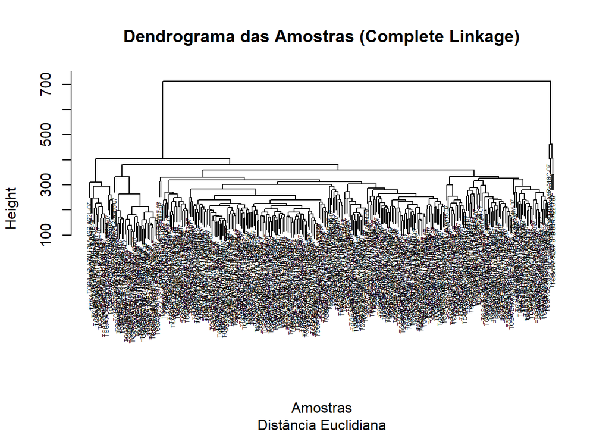

```r
# Calcular a matriz de distâncias (Euclidiana) entre as amostras
dist_amostras <- dist(t(logcounts_scaled), method = "euclidean")

# Aplicar o algoritmo hierárquico
hc_amostras <- hclust(dist_amostras, method = "complete")

# Dendrograma global
plot(hc_amostras,
     main = "Dendrograma das Amostras (Complete Linkage)",
     xlab = "Amostras",
     sub = "Distância Euclidiana",
     cex = 0.4)
```

### Heatmap Duplo (Clustering Hierárquico Visual)

```r
# Variância dos genes
gene_vars <- apply(logcounts_scaled, 1, var)

# Top 100 genes mais variáveis
top_100_genes <- names(sort(gene_vars, decreasing = TRUE))[1:100]

# Submatriz
matriz_top <- logcounts_scaled[top_100_genes, ]
```

```r
# Anotação das amostras
anotacao_col <- data.frame(
  Tipo_Amostra = clinical$sample_type
)

rownames(anotacao_col) <- rownames(clinical)

# Cores
cores_anotacao <- list(
  Tipo_Amostra = c(
    "Primary Tumor" = "#e74c3c",
    "Solid Tissue Normal" = "#3498db"
  )
)
```

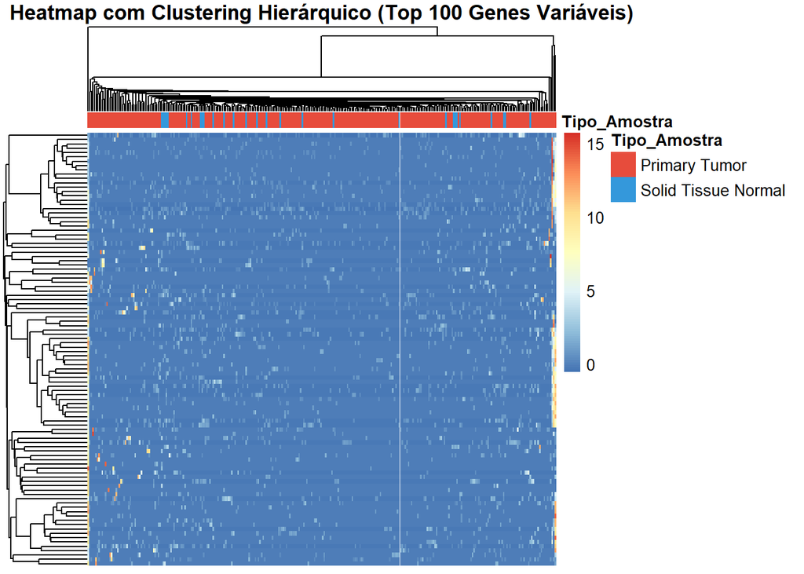

```r
pheatmap(matriz_top,
         scale = "none",
         annotation_col = anotacao_col,
         annotation_colors = cores_anotacao,
         show_rownames = FALSE,
         show_colnames = FALSE,
         clustering_method = "complete",
         main = "Heatmap com Clustering Hierárquico (Top 100 Genes Variáveis)")
```

## K-means Clustering das Amostras

O K-means clustering foi utilizado para agrupar amostras com perfis de expressão génica semelhantes, permitindo explorar padrões de separação nos dados.

### Preparação dos dados

```r
# Alinhamento dos dados
exp <- t(logcounts_scaled)
clinical2 <- clinical[colnames(logcounts_scaled), ]
sample_types <- as.factor(clinical2$sample_type)

cat("Dimensões expressão (amostras x genes):", dim(exp), "\n")
```

```
## Dimensões expressão (amostras x genes): 300 33913
```

```r
cat("Distribuição dos tipos clínicos:\n")
```

```
## Distribuição dos tipos clínicos:
```

```r
print(table(sample_types))
```

```
## sample_types
##       Primary Tumor Solid Tissue Normal
##                 271                  29
```

### K-means clustering

```r
set.seed(42)
k <- 3

km_samples <- kmeans(exp, centers = k, nstart = 50)

cat("Tamanho dos clusters:\n")
```

```
## Tamanho dos clusters:
```

```r
print(km_samples$size)
```

```
## [1]  68 228   4
```

```r
cat("\nTabela cluster vs tipo clínico:\n")
```

```
##
## Tabela cluster vs tipo clínico:
```

```r
print(table(Cluster = km_samples$cluster,
            Tipo = sample_types))
```

```
##        Tipo
## Cluster Primary Tumor Solid Tissue Normal
##       1            67                   1
##       2           200                  28
##       3             4                   0
```

### Método do cotovelo (WSS)

```r
exp_small <- exp[, order(apply(exp, 2, var), decreasing = TRUE)[1:1000]]
```

```r
wss <- c()
set.seed(42)

for (k in 2:15) {
  wss[k] <- kmeans(exp_small, centers = k, nstart = 10, iter.max = 50)$tot.withinss
}
```

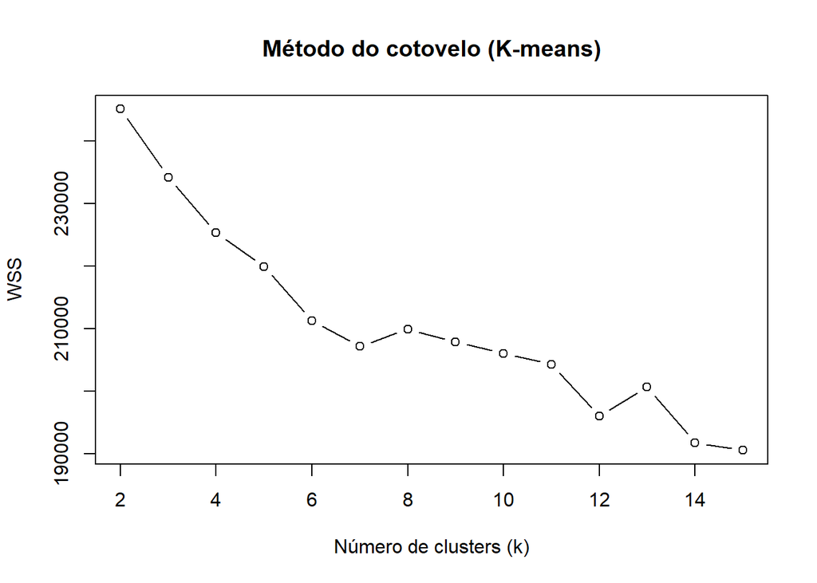

```r
plot(2:15, wss[2:15], type = "b",
     xlab = "Número de clusters (k)",
     ylab = "WSS",
     main = "Método do cotovelo (K-means)")
```

### Visualização dos clusters (PCA)

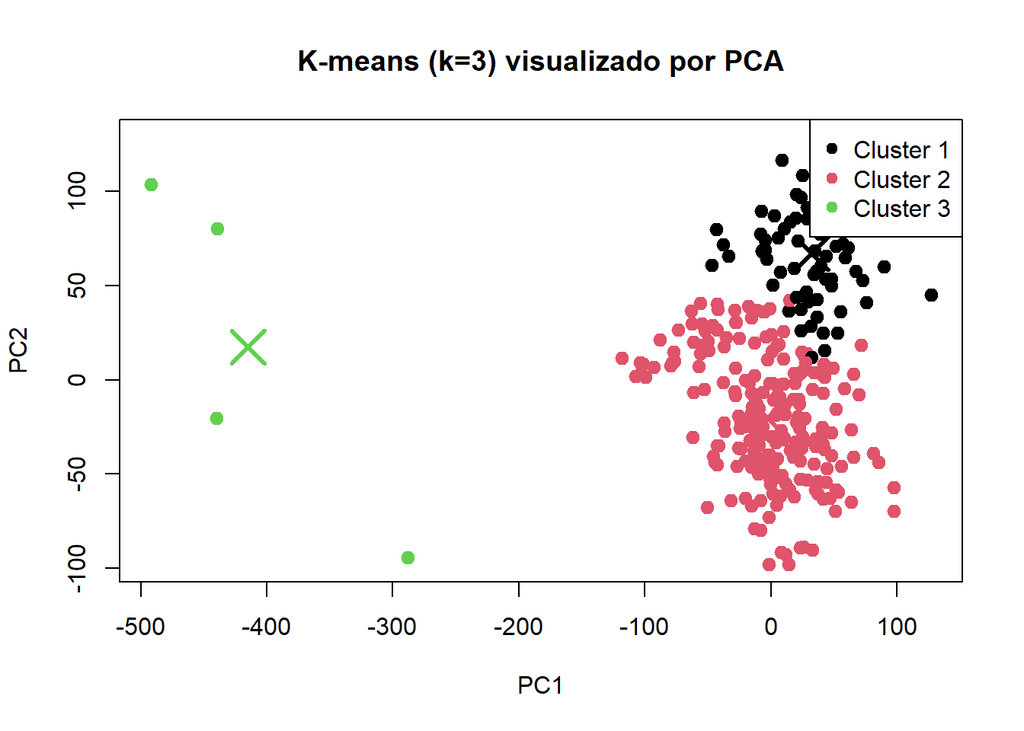

```r
pca <- prcomp(exp, scale. = TRUE)

plot(pca$x[,1], pca$x[,2],
     col = km_samples$cluster,
     pch = 19, cex = 1.2,
     xlab = "PC1", ylab = "PC2",
     main = "K-means (k=3) visualizado por PCA")

points(km_samples$centers %*% pca$rotation[,1:2],
       col = 1:k,
       pch = 4,
       cex = 3,
       lwd = 3)

legend("topright",
       legend = paste("Cluster", 1:3),
       col = 1:3,
       pch = 19)
```

```r
cluster_means <- sapply(split(as.data.frame(exp), km_samples$cluster), colMeans)
cluster_means <- t(cluster_means)

cat("Top resultados (primeiros genes):\n")
```

```
## Top resultados (primeiros genes):
```

```r
print(head(cluster_means[, 1:5]))
```

```
##   ENSG00000000003.15 ENSG00000000005.6 ENSG00000000419.13 ENSG00000000457.14
## 1         0.32708615       -0.30584337         0.28331187         -0.6903945
## 2        -0.08074049        0.08448105        -0.04433532          0.1941125
## 3        -0.95825642        0.38391758        -2.28918886          0.6722925
##   ENSG00000000460.17
## 1         0.25514794
## 2        -0.09304289
## 3         0.96593001
```

# Redução de dimensionalidade, MDS ou outras análises não Supervisionadas

Foram utilizadas técnicas de redução de dimensionalidade e métodos não supervisionados para visualizar a estrutura global dos dados e identificar padrões de agrupamento entre amostras.

## Preparação para Redução de Dimensionalidade

```r
exp_t <- t(logcounts_scaled)

cat("Dimensões após transposta (amostras x genes):", dim(exp_t), "\n")
```

```
## Dimensões após transposta (amostras x genes): 300 33913
```

```r
# Top 1000 genes mais variáveis
var_genes <- apply(logcounts_scaled, 1, var)
top_genes <- names(sort(var_genes, decreasing = TRUE))[1:1000]

exp_top <- t(logcounts_scaled[top_genes, ])

cat("Dimensões com top 1000 genes:", dim(exp_top), "\n")
```

```
## Dimensões com top 1000 genes: 300 1000
```

```r
# Standardizar os dados (recomendado antes de PCA/MDS)
exp_sc <- scale(exp_top)
```

```r
## Alinhamento com dados clínicos

# Alinhar com a matriz de expressão
clinical2 <- clinical[colnames(logcounts_scaled), ]

# Variáveis clínicas
sample_types <- factor(clinical2$sample_type)
tumor_types  <- factor(clinical2$classification_of_tumor)

# Verificação da distribuição
cat("\nDistribuição dos tipos de amostra:\n")
```

```
##
## Distribuição dos tipos de amostra:
```

```r
print(table(sample_types))
```

```
## sample_types
##       Primary Tumor Solid Tissue Normal
##                 271                  29
```

```r
cat("\nDistribuição da classificação do tumor:\n")
```

```
##
## Distribuição da classificação do tumor:
```

```r
print(table(tumor_types))
```

```
## tumor_types
##         metastasis       not reported            primary      Prior primary
##                 10                  4                278                  3
##         recurrence Subsequent Primary
##                  3                  1
```

```r
# Cores para visualização
cores <- rainbow(nlevels(sample_types))
mcols <- cores[as.integer(sample_types)]

cores_tumor_types <- rainbow(nlevels(tumor_types))
```

## PCA

```r
# PCA nos dados standardizados
pca <- prcomp(exp_sc, scale. = TRUE)
# Variância explicada por cada componente
summary(pca)
```

```
## Importance of components:
##                           PC1     PC2     PC3     PC4     PC5     PC6     PC7
## Standard deviation     13.928 7.02454 6.69996 5.19465 5.07540 4.89717 4.59213
## Proportion of Variance  0.194 0.04934 0.04489 0.02698 0.02576 0.02398 0.02109
## Cumulative Proportion   0.194 0.24334 0.28823 0.31521 0.34097 0.36496 0.38604
##                            PC8     PC9    PC10    PC11    PC12    PC13    PC14
## Standard deviation     4.52628 3.93476 3.60159 3.37296 3.18599 3.12010 3.04387
## Proportion of Variance 0.02049 0.01548 0.01297 0.01138 0.01015 0.00974 0.00927
## Cumulative Proportion  0.40653 0.42201 0.43498 0.44636 0.45651 0.46625 0.47551
##                           PC15    PC16    PC17    PC18    PC19   PC20    PC21
## Standard deviation     2.76134 2.74994 2.67848 2.61437 2.54626 2.5294 2.50503
## Proportion of Variance 0.00762 0.00756 0.00717 0.00683 0.00648 0.0064 0.00628
## Cumulative Proportion  0.48314 0.49070 0.49787 0.50471 0.51119 0.5176 0.52387
##                           PC22    PC23    PC24    PC25    PC26    PC27    PC28
## Standard deviation     2.43373 2.41263 2.36309 2.33725 2.32115 2.30780 2.28570
## Proportion of Variance 0.00592 0.00582 0.00558 0.00546 0.00539 0.00533 0.00522
## Cumulative Proportion  0.52979 0.53561 0.54119 0.54666 0.55204 0.55737 0.56259
##                           PC29    PC30    PC31    PC32    PC33    PC34    PC35
## Standard deviation     2.26612 2.23999 2.22867 2.20789 2.17690 2.15699 2.12852
## Proportion of Variance 0.00514 0.00502 0.00497 0.00487 0.00474 0.00465 0.00453
## Cumulative Proportion  0.56773 0.57275 0.57771 0.58259 0.58733 0.59198 0.59651
##                           PC36    PC37   PC38   PC39    PC40   PC41    PC42
## Standard deviation     2.10904 2.07819 2.0505 2.0487 2.03189 2.0254 2.01525
## Proportion of Variance 0.00445 0.00432 0.0042 0.0042 0.00413 0.0041 0.00406
## Cumulative Proportion  0.60096 0.60528 0.6095 0.6137 0.61781 0.6219 0.62597
##                           PC43    PC44    PC45    PC46    PC47   PC48    PC49
## Standard deviation     2.01069 1.98989 1.97889 1.95938 1.94725 1.9235 1.91588
## Proportion of Variance 0.00404 0.00396 0.00392 0.00384 0.00379 0.0037 0.00367
## Cumulative Proportion  0.63001 0.63397 0.63789 0.64173 0.64552 0.6492 0.65289
##                           PC50    PC51    PC52   PC53    PC54    PC55    PC56
## Standard deviation     1.91244 1.89422 1.88306 1.8709 1.85359 1.85043 1.84542
## Proportion of Variance 0.00366 0.00359 0.00355 0.0035 0.00344 0.00342 0.00341
## Cumulative Proportion  0.65655 0.66014 0.66368 0.6672 0.67062 0.67404 0.67745
##                           PC57    PC58    PC59    PC60    PC61    PC62    PC63
## Standard deviation     1.83488 1.82816 1.81088 1.79785 1.79210 1.77860 1.76903
## Proportion of Variance 0.00337 0.00334 0.00328 0.00323 0.00321 0.00316 0.00313
## Cumulative Proportion  0.68081 0.68416 0.68744 0.69067 0.69388 0.69704 0.70017
##                           PC64    PC65    PC66   PC67    PC68    PC69   PC70
## Standard deviation     1.76446 1.74847 1.74317 1.7316 1.71831 1.70526 1.7018
## Proportion of Variance 0.00311 0.00306 0.00304 0.0030 0.00295 0.00291 0.0029
```

[output cut: 118 more lines]

```
## Standard deviation     0.64901 0.64008 0.63690 0.6318 0.62524 0.62029 0.61410
## Proportion of Variance 0.00042 0.00041 0.00041 0.0004 0.00039 0.00038 0.00038
## Cumulative Proportion  0.99163 0.99204 0.99244 0.9928 0.99324 0.99362 0.99400
##                          PC281   PC282   PC283   PC284   PC285   PC286   PC287
## Standard deviation     0.60918 0.60578 0.60195 0.59625 0.59191 0.58832 0.58424
## Proportion of Variance 0.00037 0.00037 0.00036 0.00036 0.00035 0.00035 0.00034
## Cumulative Proportion  0.99437 0.99473 0.99510 0.99545 0.99580 0.99615 0.99649
##                          PC288   PC289   PC290   PC291   PC292  PC293   PC294
## Standard deviation     0.57263 0.56891 0.56265 0.55998 0.55561 0.5466 0.54044
## Proportion of Variance 0.00033 0.00032 0.00032 0.00031 0.00031 0.0003 0.00029
## Cumulative Proportion  0.99682 0.99714 0.99746 0.99777 0.99808 0.9984 0.99867
##                          PC295   PC296   PC297   PC298   PC299     PC300
## Standard deviation     0.53051 0.52474 0.51279 0.50840 0.49983 3.655e-15
## Proportion of Variance 0.00028 0.00028 0.00026 0.00026 0.00025 0.000e+00
## Cumulative Proportion  0.99895 0.99923 0.99949 0.99975 1.00000 1.000e+00
```

```r
# PCA loadings (contribuição dos genes para cada componente)
loadings <- pca$rotation

cat("Genes mais influentes \n\n")
```

```
## Genes mais influentes
```

```r
cat("Genes PC1:\n")
```

```
## Genes PC1:
```

```r
top_pc1 <- head(sort(abs(loadings[,1]), decreasing = TRUE), 10)
print(top_pc1)
```

```
## ENSG00000201554.1 ENSG00000278880.1 ENSG00000241546.1 ENSG00000249100.1
##        0.06733639        0.06688612        0.06667028        0.06618052
## ENSG00000260832.1 ENSG00000213659.4 ENSG00000259571.2 ENSG00000227658.1
##        0.06609705        0.06594307        0.06560395        0.06557961
## ENSG00000235429.1 ENSG00000234784.2
##        0.06551063        0.06542618
```

```r
cat("\nGenes PC2:\n")
```

```
##
## Genes PC2:
```

```r
top_pc2 <- head(sort(abs(loadings[,2]), decreasing = TRUE), 10)
print(top_pc2)
```

```
## ENSG00000165186.12  ENSG00000106537.8  ENSG00000167912.6  ENSG00000200385.1
##         0.10045676         0.09608357         0.09366318         0.08823026
##  ENSG00000286010.1 ENSG00000112096.19  ENSG00000134760.6  ENSG00000286208.1
##         0.08796514         0.08709097         0.08549271         0.08365382
##  ENSG00000102678.7  ENSG00000276850.5
##         0.08267940         0.08215249
```

```r
# Variância explicada por componente principal
var_exp <- summary(pca)$importance[2, ]

cat("Variância explicada (PCA)\n\n")
```

```
## Variância explicada (PCA)
```

```r
cat("PC1:", round(var_exp[1] * 100, 2), "%\n")
```

```
## PC1: 19.4 %
```

```r
cat("PC2:", round(var_exp[2] * 100, 2), "%\n")
```

```
## PC2: 4.93 %
```

```r
cat("PC3:", round(var_exp[3] * 100, 2), "%\n")
```

```
## PC3: 4.49 %
```

```r
cat("PC4:", round(var_exp[4] * 100, 2), "%\n")
```

```
## PC4: 2.7 %
```

```r
cat("PC5:", round(var_exp[5] * 100, 2), "%\n")
```

```
## PC5: 2.58 %
```

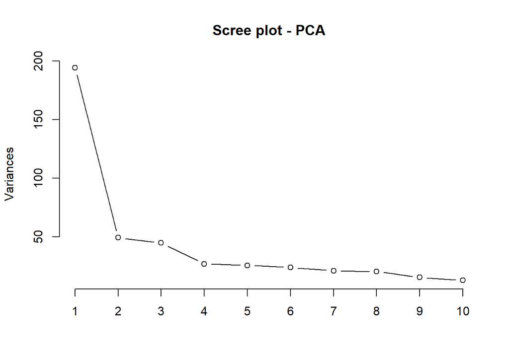

```r
# Scree plot - variância explicada por componente
plot(pca,
     type = "l",
     main = "Scree plot - PCA",
     )
```

### Sample Type

A coloração dos pontos é baseada no tipo de amostra (sample_type), permitindo distinguir entre diferentes origens biológicas das amostras.

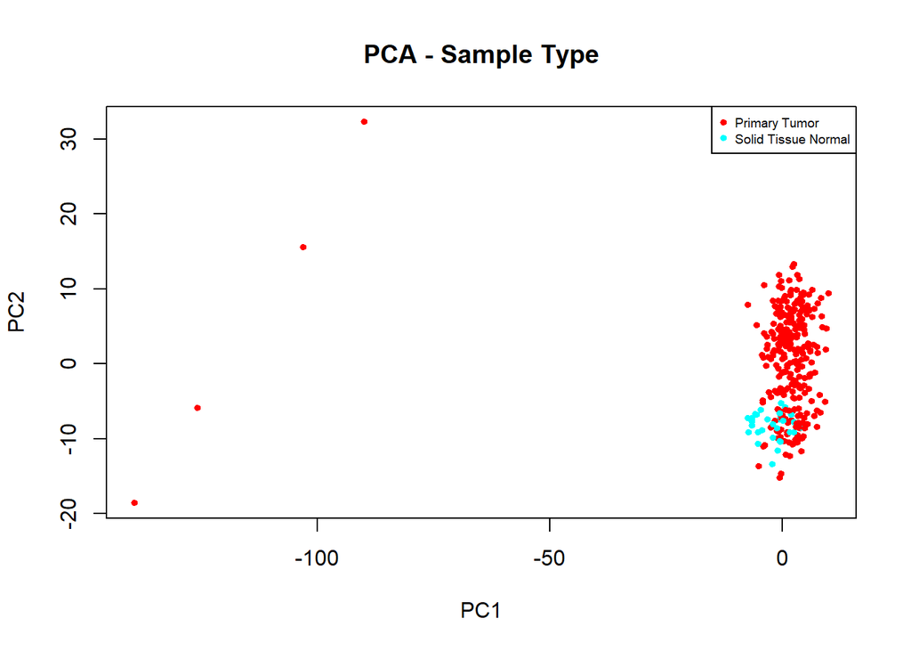

```r
plot(pca$x[,1], pca$x[,2],
     col = mcols,
     pch = 19,
     cex  = 0.6,
     xlab = "PC1",
     ylab = "PC2",
     main = "PCA - Sample Type")
legend("topright",
       legend = levels(sample_types),
       col = cores,
       pch = 19,
       cex = 0.6)
```

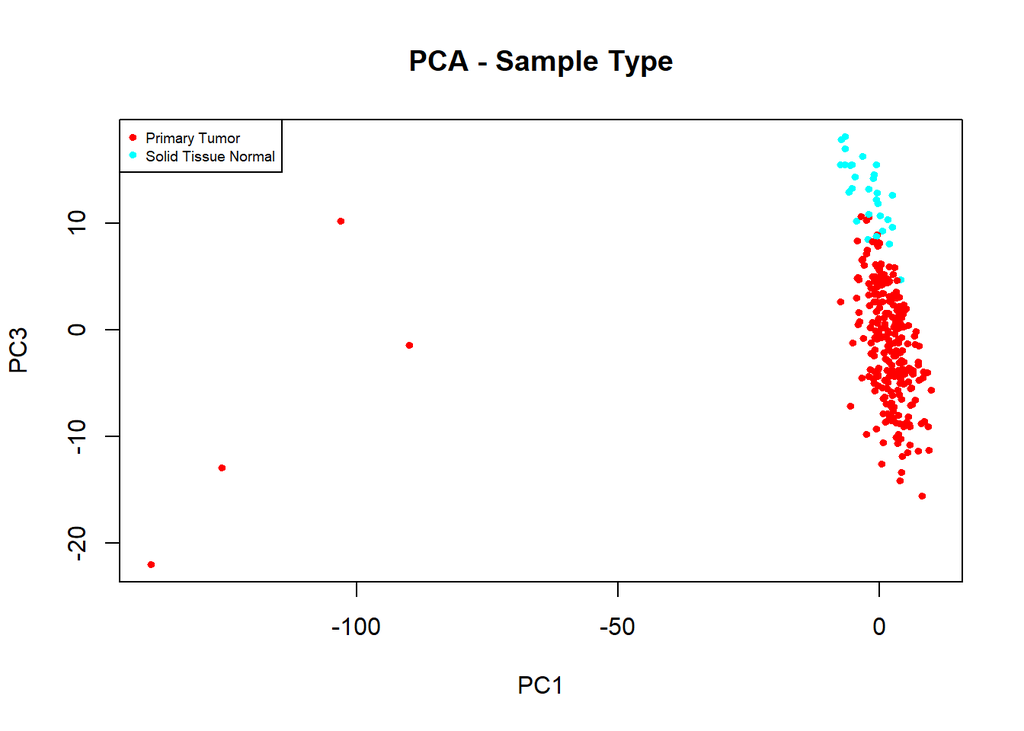

```r
plot(pca$x[,1], pca$x[,3],
     col = mcols,
     pch = 19,
     cex  = 0.6,
     xlab = "PC1",
     ylab = "PC3",
     main = "PCA - Sample Type")
legend("topleft",
       legend = levels(sample_types),
       col = cores,
       pch = 19,
       cex = 0.6)
```

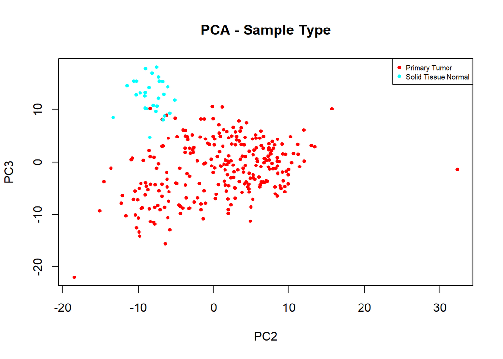

```r
plot(pca$x[,2], pca$x[,3],
     col = mcols,
     pch = 19,
     cex  = 0.6,
     xlab = "PC2",
     ylab = "PC3",
     main = "PCA - Sample Type")
legend("topright",
       legend = levels(sample_types),
       col = cores,
       pch = 19,
       cex = 0.6)
```

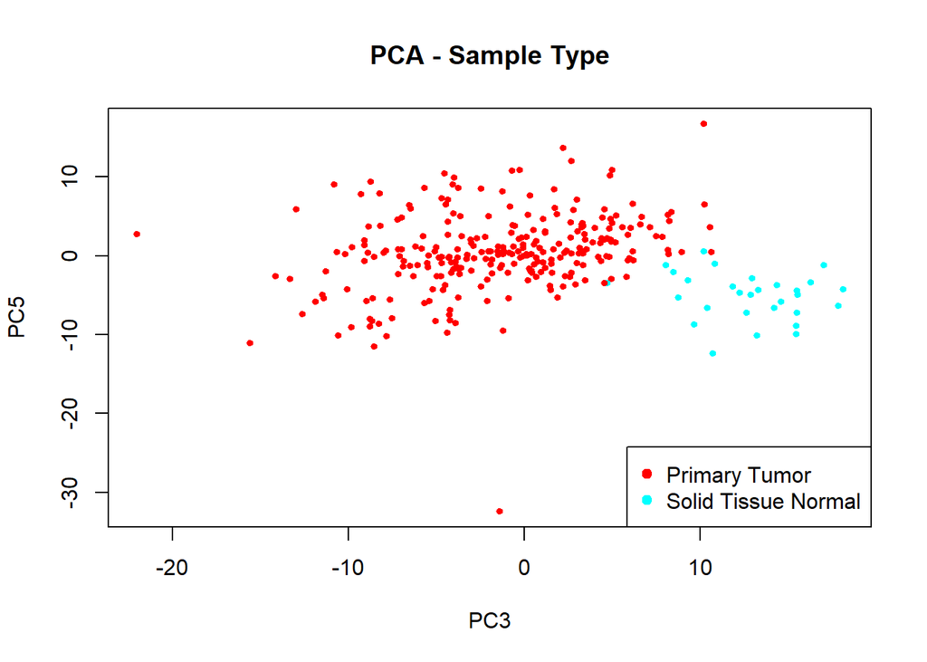

```r
plot(pca$x[,3], pca$x[,5],
     col = mcols,
     pch = 19,
     cex  = 0.6,
     xlab = "PC3",
     ylab = "PC5",
     main = "PCA - Sample Type")
legend("bottomright",
       legend = levels(sample_types),
       col = cores,
       pch = 19)
```

### Classificação do tumor

A coloração dos pontos é baseada na classificação clínica do tumor (classification_of_tumor), permitindo avaliar a separação entre subtipos tumorais.

[figure not shown]

```r
plot(pca$x[,1], pca$x[,2],
     col = as.numeric(tumor_types),
     pch = 19,
     cex  = 0.6,
     xlab = "PC1",
     ylab = "PC2",
     main = "PCA - Tumor definition")
legend("topleft",
       legend = levels(tumor_types),
       col = cores_tumor_types,
       pch = 19,
       cex = 0.6)
```

[figure not shown]

```r
plot(pca$x[,1], pca$x[,3],
     col = as.numeric(tumor_types),
     pch = 19,
     cex  = 0.6,
     xlab = "PC1",
     ylab = "PC3",
     main = "PCA - Tumor definition")
legend("topleft",
       legend = levels(tumor_types),
       col = cores_tumor_types,
       pch = 19,
       cex = 0.6)
```

[figure not shown]

```r
plot(pca$x[,2], pca$x[,3],
     col = as.numeric(tumor_types),
     pch = 19,
     cex  = 0.6,
     xlab = "PC2",
     ylab = "PC3",
     main = "PCA - Tumor definition")
legend("topright",
       legend = levels(tumor_types),
       col = cores_tumor_types,
       pch = 19,
       cex = 0.6)
```

[figure not shown]

```r
plot(pca$x[,3], pca$x[,5],
     col = as.numeric(tumor_types),
     pch = 19,
     cex  = 0.6,
     xlab = "PC3",
     ylab = "PC5",
     main = "PCA - Tumor definition")
legend("bottomleft",
       legend = levels(tumor_types),
       col = cores_tumor_types,
       pch = 19,
       cex = 0.6)
```

## MDS Classico (Metrico)

```r
# Calcular matriz de distancias euclidianas
dist_mat <- dist(exp_sc, method = "euclidean")
```

```r
# Correr MDS classico (cmdscale)
cmd_mds <- cmdscale(dist_mat, k = 3, eig = TRUE)
```

```r
# Eigenvalues
eig <- cmd_mds$eig
var_exp <- eig / sum(abs(eig)) * 100

# Proporcao de variancia explicada por cada coordenada
var_c1 <- cmd_mds$eig[2] / sum(abs(cmd_mds$eig)) * 100
var_c2 <- cmd_mds$eig[3] / sum(abs(cmd_mds$eig)) * 100
var_c3 <- cmd_mds$eig[4] / sum(abs(cmd_mds$eig)) * 100

lab_c1 <- paste0("Coordinate 1 (", round(var_c1, 2), "%)")
lab_c2 <- paste0("Coordinate 2 (", round(var_c2, 2), "%)")
lab_c3 <- paste0("Coordinate 3 (", round(var_c3, 2), "%)")

cat("Variancia explicada:\n")
```

```
## Variancia explicada:
```

```r
cat("  Coordenada 1:", round(var_c1, 2), "%\n")
```

[output not shown]

```r
cat("  Coordenada 2:", round(var_c2, 2), "%\n")
```

[output not shown]

```r
cat("  Coordenada 3:", round(var_c3, 2), "%\n")
```

[output not shown]

[figure not shown]

```r
# Grafico MDS classico 2D
plot(cmd_mds$points[, c(1, 2)],
     xlab = lab_c1, ylab = lab_c2,
     col  = mcols, pch = 19, cex = 0.8,
     main = "MDS Classico (Metrico) - TCGA-BRCA")
legend("topright",
       legend = levels(sample_types),
       col    = cores,
       pch    = 19, cex = 0.6)
```

## MDS Nao Metrico

```r
# Evitar distâncias zero (necessário para isoMDS)
dist_mat2 <- dist_mat
dist_mat2[dist_mat2 == 0] <- 0.00001
```

```r
# Correr isoMDS
set.seed(42)

ord <- isoMDS(dist_mat2, k = 2)
cat("Stress do MDS não métrico:", round(ord$stress, 2), "\n")
```

```
## Stress do MDS não métrico: 1.04
```

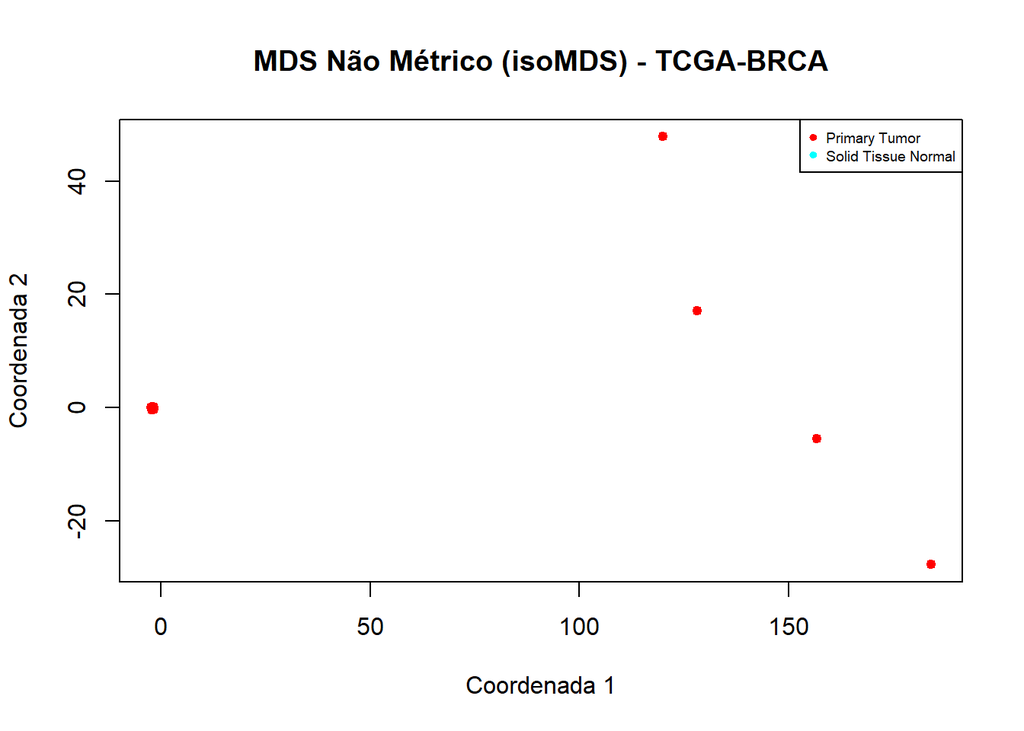

```r
plot(ord$points[, c(1, 2)],
     xlab = "Coordenada 1",
     ylab = "Coordenada 2",
     col  = mcols,
     pch = 19,
     cex = 0.8,
     main = "MDS Não Métrico (isoMDS) - TCGA-BRCA")
legend("topright",
       legend = levels(sample_types),
       col    = cores,
       pch    = 19,
       cex = 0.6)
```